# Problem 1 & 2 - Methane Emissions from Landfills, Carbon Mapper Plumes

```python
import pandas as pd
import geopandas as gpd
import numpy as np
import matplotlib.pyplot as plt
```

## i. Provide a merged landfill dataset of the California GHGRP and LMOP data for 2021. You can merge the dataset on GHGRP ID. You may have to deal with duplicates.

- Here I load and inspect the data, inspecting for errors and duplicates, getting a sense of what the data looks like.

```python
ghgrp = gpd.read_file(r'D:\OneDrive_1_5-19-2023\Datasets for takehome\GHGRP flight_CA_2021.csv')
lmop = gpd.read_file(r'D:\OneDrive_1_5-19-2023\Datasets for takehome\lmopdata_CA.csv')
```

```python
#lmop.info()
ghgrp.info()
```

```
<class 'geopandas.geodataframe.GeoDataFrame'>
RangeIndex: 127 entries, 0 to 126
Data columns (total 13 columns):
 #   Column                           Non-Null Count  Dtype
---  ------                           --------------  -----
 0   REPORTING YEAR                   127 non-null    object
 1   FACILITY NAME                    127 non-null    object
 2   GHGRP ID                         127 non-null    object
 3   REPORTED ADDRESS                 127 non-null    object
 4   LATITUDE                         127 non-null    object
 5   LONGITUDE                        127 non-null    object
 6   CITY NAME                        127 non-null    object
 7   STATE                            127 non-null    object
 8   ZIP CODE                         127 non-null    object
 9   PARENT COMPANIES                 127 non-null    object
 10  GHG QUANTITY (METRIC TONS CO2e)  127 non-null    object
 11  SUBPARTS                         127 non-null    object
 12  geometry                         0 non-null      geometry
dtypes: geometry(1), object(12)
memory usage: 6.5+ KB
```

```python
#lmop
print('Unique counts ghgrp')
for col in ghgrp.columns:
    print(col,len(np.unique(ghgrp[col]))) if col != 'geometry' else print('geometry null')

print('')
print('Unique counts lmop')
for col in lmop.columns:
    print(col,len(np.unique(lmop[col]))) if col != 'geometry' else print('geometry null')
```

```
Unique counts ghgrp
REPORTING YEAR 1
FACILITY NAME 127
GHGRP ID 127
REPORTED ADDRESS 124
LATITUDE 126
LONGITUDE 126
CITY NAME 121
STATE 1
ZIP CODE 118
PARENT COMPANIES 71
GHG QUANTITY (METRIC TONS CO2e) 98
SUBPARTS 5
geometry null

Unique counts lmop
GHGRP ID 123
Landfill ID 300
Landfill Name 300
State 1
Physical Address 242
City 259
Zip Code 247
Latitude 282
Longitude 283
Ownership Type 2
Landfill Owner Organization(s) 146
Year Landfill Opened 53
Landfill Closure Year 110
Current Landfill Status 3
Waste in Place (tons) 236
Waste in Place Year 30
LFG Collection System In Place? 4
LFG Collected (mmscfd) 142
LFG Flared (mmscfd) 109
Project ID 404
Current Project Status 8
Project Name 40
Project Start Date 136
Project Shutdown Date 68
Project Type Category 4
LFG Energy Project Type 14
RNG Delivery Method 4
Actual MW Generation 100
Rated MW Capacity 69
LFG Flow to Project (mmscfd) 96
Current Year Emission Reductions (MMTCO2e/yr) - Direct 64
Current Year Emission Reductions (MMTCO2e/yr) - Avoided 61
geometry null
```

#### According to the LMOP documentation, the 'Waste in Place Year' field should correspond to that year's waste.

- I checked their website for 2021 data, and it appears there is some newer data available for 2021.
- This is something I'd ask for further clarification on, but I'm fairly confident that WIP is cumulative for all WIP years up to the current year based on quick research from this source: westcoastclimateforum.com/content/landfill-wip-and-mc-waste-place-methodology-landfilled-waste.

```python
print(np.unique(lmop['Waste in Place Year'])), np.unique(ghgrp['REPORTING YEAR'])
```

```
['' '1965' '1974' '1980' '1981' '1983' '1985' '1987' '1990' '1992' '1993'
 '1995' '1996' '1997' '1998' '2000' '2002' '2004' '2006' '2007' '2008'
 '2009' '2011' '2012' '2013' '2014' '2015' '2016' '2019' '2020']
```

```
(None, array(['2021'], dtype=object))
```

```python
# Only performing the analysis with records that have a GHGRP ID match. LMOP has records w/out ids.
lmop = lmop.loc[lmop['GHGRP ID']!= '']
```

```python
# Check for count of unique ID records.
print('Count of unique LMOP IDs', len(np.unique(lmop['GHGRP ID'])))
print('Count of unique GHGRP IDs', len(np.unique(ghgrp['GHGRP ID'])))
```

```
Count of unique LMOP IDs 122
Count of unique GHGRP IDs 127
```

#### I visualized the data in QGIS to inspect the cause for the discrepancy in unique GHGRP ID's.

- I also checked the possibility of there being missing ID's in the LMOP dataset by using the hub distance tool in QGIS on the records w/no ID. This tool gives the nearest point in another dataset with distance, I quickly checked the closest points in both datasets to check for similar addresses or facility names.
- There weren't any close matches so I made the decision not to assume these should be cleaned/matched further.

##### The data needed from the LMOP dataset is waste in place. Check the duplicated records before combining them, making sure the duplicates don't have different Waste values before de-duping.

```python
# create a series that shows if an ID is a duplicate
lmop['ID_Waste'] = lmop['GHGRP ID'] + lmop['Waste in Place (tons)']
check_dupes = lmop.duplicated(subset='ID_Waste', keep=False)
print('LMOP duplicates exist:',check_dupes.unique())
```

```
LMOP duplicates exist: [ True False]
```

```python
# create another dataframe that then checks if all 'Waste in Place' values are the same for each duplicated ID
id_waste = lmop[check_dupes][['GHGRP ID','Waste in Place (tons)']]
id_waste['dup_id_waste'] = id_waste['GHGRP ID'] + id_waste['Waste in Place (tons)']
check_dupe_values = id_waste.duplicated(subset='dup_id_waste', keep=False)
print('LMOP duplicates have the same WIP value:',check_dupe_values.unique())
```

```
LMOP duplicates have the same WIP value: [ True]
```

```python
# Define what columns determine whether or not the record is a duplicate, and remove duplicates.
columns = ['GHGRP ID', 'Waste in Place (tons)']

# Drop the duplicates and check the shape.
lmop_cleaned = lmop.drop_duplicates(subset=columns)
lmop_cleaned.shape
```

```
(122, 34)
```

```python
# Check for complete lat/long data
print(ghgrp.LATITUDE.min(),ghgrp.LATITUDE.max(), ghgrp.LONGITUDE.min(), ghgrp.LONGITUDE.max())
print(lmop_cleaned.Latitude.min(), lmop_cleaned.Latitude.max(),lmop_cleaned.Longitude.min(),lmop_cleaned.Longitude.max())
```

```
32.6055 40.76235 -115.483038 -124.08941
32.604 40.76167 -115.526 -124.08833
```

```python
merged_df = pd.merge(lmop_cleaned, ghgrp, left_on='GHGRP ID', right_on='GHGRP ID')
merged_df.shape
```

```
(122, 46)
```

### ii. Compute a column for methane emissions data, assuming that 50% of the GHG QUANTITY (METRIC TONS CO2e) provided in the GHGRP dataset is from methane.

```python
# Assuming half the emissions from 'GHG QUANTITY (METRIC TONS CO2e)' field is from methane
# convert the column to float and multiply by .5
methane = merged_df[ 'GHG QUANTITY (METRIC TONS CO2e)'].astype(float) * .5

# convert metric tons to kg
merged_df['methane_kg'] = methane * 1000
```

### iii. Calculate methane intensity in kg CH4/ton of waste in place.

```python
wip = pd.to_numeric(merged_df['Waste in Place (tons)'].str.replace(',',''), errors='coerce')
```

```python
merged_df['methane_intensity'] = merged_df['methane_kg'] / wip.astype(float)
```

### iv. Print a list of the top 10 most methane intensive landfills in California in 2021

```python
fields = ['FACILITY NAME','methane_intensity', 'Waste in Place (tons)', 'methane_kg']
fields_formatted = ['Facility Name','Methane Intensity (kg/ton)','Waste in Place (tons)','Total Methane (kg)']

top_10 = merged_df.sort_values('methane_intensity', ascending=False)[fields][0:10]
top_10.index = np.arange(1, len(top_10) + 1)
top_10['FACILITY NAME']=top_10['FACILITY NAME'].str.title()
top_10.columns = fields_formatted
top_10
```

|  | Facility Name | Methane Intensity (kg/ton) | Waste in Place (tons) | Total Methane (kg) |
| --- | --- | --- | --- | --- |
| 1 | Clover Flat Landfill | 17.428717 | 1,618,048 | 28200500.0 |
| 2 | Johnson Canyon Sanitary Landfill | 11.565969 | 3,557,549 | 41146500.0 |
| 3 | Monterey Regional Waste Management District | 10.182087 | 13,051,156 | 132888000.0 |
| 4 | Billy Wright Landfill | 8.352969 | 2,419,918 | 20213500.0 |
| 5 | Landers Sanitary Landfill | 8.329058 | 2,713,272 | 22599000.0 |
| 6 | Tehama County/Red Bluff Landfill | 7.618454 | 1,890,541 | 14403000.0 |
| 7 | Barstow Sanitary Landfill | 7.521295 | 2,914,857 | 21923500.0 |
| 8 | Azusa Land Reclamation Co Inc Inert Lf | 7.351203 | 7,900,000 | 58074500.0 |
| 9 | Fairmead Solid Waste Disposal Site | 7.045151 | 5,028,565 | 35427000.0 |
| 10 | West Central Landfill | 6.348693 | 5,139,404 | 32628500.0 |

### v. Using the California county shapefile information provided, aggregate methane emissions by county. Print the name of the county emitting the most landfill methane.

```python
# Add geometry column to df
merged_df=gpd.GeoDataFrame(merged_df, geometry=gpd.points_from_xy(merged_df.Longitude, merged_df.Latitude), crs="EPSG:4326")
```

```python
ca_counties = gpd.read_file(r'D:\OneDrive_1_5-19-2023\Datasets for takehome\CA County data\CA_Counties_TIGER.shp')
```

```python
ca_counties.crs
```

```
<Projected CRS: EPSG:3857>
Name: WGS 84 / Pseudo-Mercator
Axis Info [cartesian]:
- X[east]: Easting (metre)
- Y[north]: Northing (metre)
Area of Use:
- name: World between 85.06°S and 85.06°N.
- bounds: (-180.0, -85.06, 180.0, 85.06)
Coordinate Operation:
- name: Popular Visualisation Pseudo-Mercator
- method: Popular Visualisation Pseudo Mercator
Datum: World Geodetic System 1984
- Ellipsoid: WGS 84
- Prime Meridian: Greenwich
```

```python
ca_counties = ca_counties.to_crs("EPSG:4326")
```

```python
# Join the county data with landfill geodataframe
merged_counties = gpd.sjoin(merged_df, ca_counties, how="inner")
counties_methane = gpd.sjoin(ca_counties,merged_df,  how="left")
```

```python
len(merged_counties)
```

```
122
```

```python
county_methane = merged_counties.groupby(['NAME']).sum('methane_kg').reset_index()

# Update units for brevity
county_methane['methane_tons'] = county_methane['methane_kg'] / 907.2
county_methane = county_methane[['NAME','methane_tons']].sort_values('methane_tons', ascending=False)
county_methane.columns = ['County','Methane Produced, metric tons']
county_methane.index = county_methane['County']
```

```python
county_methane.iloc[0]
```

```
County                           Los Angeles
Methane Produced, metric tons         825789
Name: Los Angeles, dtype: object
```

### The top methane-producing county is LA county.

- This makes sense because it is the most populous county in CA, and therefore more landfill waste is likely to be produced by its residents.
- However, some counties in this analysis show no production of methane from landfills, which seems unlikely. There is a lack of GHGRP matching records in these counties.

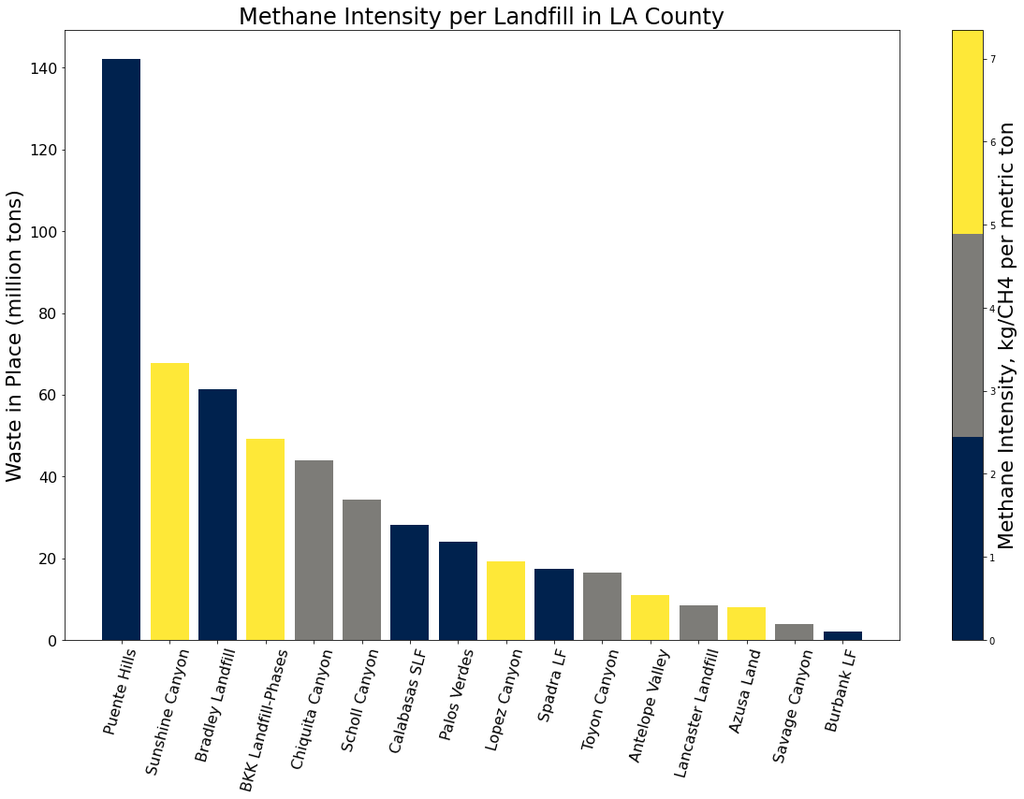

```python
import matplotlib.cm as cm
from matplotlib.colors import Normalize

LA_points = merged_counties.loc[merged_counties.NAME == 'Los Angeles']
LA_points['Waste in Place (tons)'] = pd.to_numeric(LA_points['Waste in Place (tons)'].str.replace(',',''),errors='coerce')
LA_points = LA_points.sort_values('Waste in Place (tons)', ascending=False)

# Shorten for readability
LA_points['Landfill Name'] = LA_points['Landfill Name'].str.split().str[:2].str.join(' ')

plt.figure(figsize=(20, 12))

# 3 bins to more easily distinguish methane intensity per each facility
LA_points['quantile'] = pd.qcut(LA_points['methane_intensity'], q=3, labels=False)
cmap = cm.get_cmap('cividis',3)
plt.bar(LA_points['Landfill Name'], LA_points['Waste in Place (tons)']/ 1e6, color=cmap(LA_points['quantile'] / 2),align="center")

plt.title('Methane Intensity per Landfill in LA County',size = 24)
plt.ylabel('Waste in Place (million tons)',size = 22)
plt.gca().yaxis.set_major_formatter('{:,.0f}'.format)

plt.xticks(rotation=75, size=16)
plt.yticks(size=16)

sm = cm.ScalarMappable(cmap=cmap)
sm.set_array(LA_points['methane_intensity'])
cbar = plt.colorbar(sm)
cbar.set_label('Methane Intensity, kg/CH4 per metric ton', size=22)

plt.show()
```

#### This figure juxtaposes the emission intensity with the waste created by each landfill in the highest methane-producing county of Los Angeles. Interestingly, there doesn't seem to be a clear pattern with landfill size and the intensity of emissions. It would be worth investigating the cause, whether that's a management practice or age of the landfill for example.

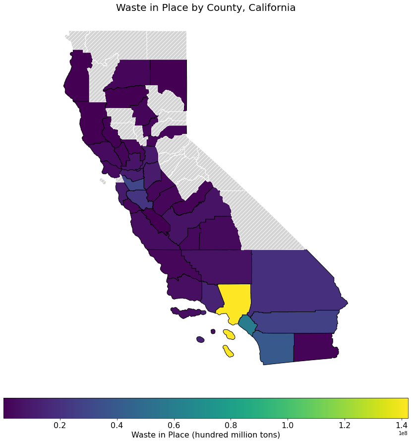

```python
from matplotlib.cm import ScalarMappable

counties_methane['Waste in Place (tons)']= pd.to_numeric(counties_methane['Waste in Place (tons)'].str.replace(',','').fillna(np.nan), errors='coerce')
ca_counties_sum_methane = counties_methane.groupby('NAME').sum().reset_index()
county_geom=counties_methane[['NAME', 'geometry']].drop_duplicates(subset='NAME')
ca_counties_sum_methane = ca_counties_sum_methane.merge(county_geom, on='NAME').replace(0,np.nan)

ax = ca_counties_sum_methane.plot(
    column='Waste in Place (tons)',
    figsize=(18, 15),
    cmap='viridis',
    edgecolor='black',
    missing_kwds={
        "color": "lightgrey",
        "edgecolor": "white",
        "hatch": "///",
        "label": "No Data",
    })

ax.set_axis_off()
plt.title('Waste in Place by County, California', size=20)
normalize = Normalize(vmin=counties_methane['Waste in Place (tons)'].min(),
                 vmax=counties_methane['Waste in Place (tons)'].max())
sm = ScalarMappable(cmap='viridis', norm=normalize)
sm.set_array([])
cbar = plt.colorbar(sm, label='Waste in Place (hundred million tons)', ax=ax,
                    fraction=0.05, pad=0.04, orientation='horizontal')
cbar.ax.tick_params(labelsize=16)
cbar.ax.set_xlabel('Waste in Place (hundred million tons)', fontsize=16)

plt.show()
```

#### This figure shows the total waste in place aggregated by county. Los Angeles is clearly leading in the amount of waste it produces, but it would be interesting to normalize this for population, number of landfills, or another assessment of landfill management practices by county.

## Part II - Carbon Mapper Plumes

#### Use the provided Carbon Mapper 2022 plume dataset to match measured plumes in California to the landfill site latitude/longitude locations outlined in the LMOP dataset, using a buffer radius of 5 miles.

```python
cm_df = gpd.read_file(r'D:\OneDrive_1_5-19-2023\Datasets for takehome\Carbon Mapper 2022 plume.csv')
```

```python
cm_df = gpd.GeoDataFrame(cm_df, geometry=gpd.points_from_xy(cm_df.plume_lon, cm_df.plume_lat), crs="EPSG:4326")
cm_df
```

|  | source_id | source_type | plume_id | plume_lat | plume_lon | datetime | ipcc_sector | emission | emission_uncertainty | plume_tif_url | rgb_tif_url | geometry |
| --- | --- | --- | --- | --- | --- | --- | --- | --- | --- | --- | --- | --- |
| 0 | M0020 |  | ang20220523t195357-A | 35.4151122 | -118.9452 | 2022-05-23T19:53:57 |  | 42.3783662 | 20.0262033 | {s3}/AVIRIS/ang20220523t195357-A_r229_c473_ctr... | {s3}/AVIRIS/ang20220523t195357-A_r229_c473_rgb... | POINT (-118.94520 35.41511) |
| 1 | M0020 |  | ang20220523t195723-A | 35.4149719 | -118.94521 | 2022-05-23T19:57:23 |  | 31.6161782 | 11.1406924 | {s3}/AVIRIS/ang20220523t195723-A_r73_c476_ctr.tif | {s3}/AVIRIS/ang20220523t195723-A_r73_c476_rgb.tif | POINT (-118.94521 35.41497) |
| 2 | M0020 |  | ang20220523t200841-A | 35.415113 | -118.94517 | 2022-05-23T20:08:41 |  | 67.252813 | 34.8235237 | {s3}/AVIRIS/ang20220523t200841-A_r180_c477_ctr... | {s3}/AVIRIS/ang20220523t200841-A_r180_c477_rgb... | POINT (-118.94517 35.41511) |
| 3 | M0020 |  | ang20220523t201202-A | 35.415036 | -118.94528 | 2022-05-23T20:12:02 |  | 66.2496065 | 6.29857052 | {s3}/AVIRIS/ang20220523t201202-A_r-13_c189_ctr... | {s3}/AVIRIS/ang20220523t201202-A_r-13_c189_rgb... | POINT (-118.94528 35.41504) |
| 4 | M0020 |  | ang20220523t201543-A | 35.415167 | -118.94525 | 2022-05-23T20:15:43 |  | 54.3720273 | 12.0758546 | {s3}/AVIRIS/ang20220523t201543-A_r156_c151_ctr... | {s3}/AVIRIS/ang20220523t201543-A_r156_c151_rgb... | POINT (-118.94525 35.41517) |
| ... | ... | ... | ... | ... | ... | ... | ... | ... | ... | ... | ... | ... |
| 798 | N0025 |  | GAO20220627t150152p0000-A | 47.875255 | -102.689158 | 2022-06-27T15:01:52 |  | 1797.340473 | 568.0257869 | {s3}/AVIRIS/GAO20220627t150152p0000-A_r560_c14... | {s3}/AVIRIS/GAO20220627t150152p0000-A_r560_c14... | POINT (-102.68916 47.87526) |
| 799 | N0026 |  | GAO20220627t163654p0000-A | 47.972826 | -103.203271 | 2022-06-27T16:36:54 |  | 951.9103045 | 204.199478 | {s3}/AVIRIS/GAO20220627t163654p0000-A_r825_c30... | {s3}/AVIRIS/GAO20220627t163654p0000-A_r825_c30... | POINT (-103.20327 47.97283) |
| 800 | N0027 |  | GAO20220627t171557p0000-A | 48.006602 | -103.389418 | 2022-06-27T17:15:57 |  | 665.9538803 | 251.3350401 | {s3}/AVIRIS/GAO20220627t171557p0000-A_r1030_c4... | {s3}/AVIRIS/GAO20220627t171557p0000-A_r1030_c4... | POINT (-103.38942 48.00660) |
| 801 | N0028 |  | GAO20220627t173742p0000-A | 48.051505 | -103.219657 | 2022-06-27T17:37:42 |  | 416.2996651 | 96.79140097 | {s3}/AVIRIS/GAO20220627t173742p0000-A_r370_c63... | {s3}/AVIRIS/GAO20220627t173742p0000-A_r370_c63... | POINT (-103.21966 48.05150) |
| 802 | N0029 |  | GAO20220627t175441p0000-A | 48.053085 | -102.872965 | 2022-06-27T17:54:41 |  | 1535.473059 | 670.5193824 | {s3}/AVIRIS/GAO20220627t175441p0000-A_r738_c83... | {s3}/AVIRIS/GAO20220627t175441p0000-A_r738_c83... | POINT (-102.87296 48.05309) |

803 rows × 12 columns

```python
# Convert miles to meters for geopandas to buffer
fivemiles_meters = 8046.72
```

```python
cm_df['five_miles'] = cm_df.to_crs('EPSG:32610').geometry.buffer(fivemiles_meters)
cm_buffer =  gpd.GeoDataFrame(cm_df, geometry=cm_df['five_miles'], crs='EPSG:32610')
```

```python
cm_buffer = gpd.clip(cm_buffer, ca_counties.to_crs('EPSG:32610'))
```

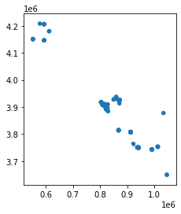

```python
cm_buffer.plot()
```

```python
# Add geometry data to the LMOP file, and select points within the Carbon Mapper buffers
lmop = gpd.GeoDataFrame(lmop_cleaned, geometry=gpd.points_from_xy(lmop_cleaned.Longitude, lmop_cleaned.Latitude), crs='EPSG:4326')

lmop=lmop.to_crs('EPSG:32610')
poly_union = cm_buffer.geometry.unary_union

lmop_cm = lmop[lmop.within(poly_union)]

# Then join to get the plume attributes.
lmop_cm = gpd.sjoin(lmop_cm, cm_buffer, how='left')
```

```python
wip = pd.to_numeric(lmop_cm['Waste in Place (tons)'].str.replace(',',''), errors='coerce')
lmop_cm['methane_intensity'] = lmop_cm['emission'].astype(float) / wip
```

```python
# Highest Methane Plume table
lmop_cm_highest = lmop_cm[['Landfill Name', 'emission','City', 'Waste in Place (tons)']]
lmop_cm_highest.columns = ['Landfill Name', 'Methane Plume Volume','City', 'Waste in Place (tons)']
lmop_cm_highest['Methane Plume Volume'] = pd.to_numeric(lmop_cm_highest['Methane Plume Volume'])
lmop_cm_highest = lmop_cm_highest.sort_values('Methane Plume Volume',ascending=False)
```

```python
lmop_cm_highest.index = np.arange(1, len(lmop_cm_highest) + 1)
lmop_cm_highest
```

|  | Landfill Name | Methane Plume Volume | City | Waste in Place (tons) |
| --- | --- | --- | --- | --- |
| 1 | Sunnyvale LF | 6470.644088 | Sunnyvale | 2,300,000 |
| 2 | All Purpose Landfill | 6470.644088 | Santa Clara | 5,501,512 |
| 3 | Tri-Cities Landfill | 6470.644088 | Fremont | 13,899,918 |
| 4 | Newby Island SLF Phases I, II, & III | 6470.644088 | Milpitas | 33,338,536 |
| 5 | Tri-Cities Landfill | 3669.390570 | Fremont | 13,899,918 |
| ... | ... | ... | ... | ... |
| 127 | Bakersfield City Landfill | 20.487261 | Bakersfield |  |
| 128 | China Grade SLF | 17.016561 | Bakersfield | 3,608,940 |
| 129 | Bakersfield City Landfill | 17.016561 | Bakersfield |  |
| 130 | Bakersfield City Landfill | 9.571454 | Bakersfield |  |
| 131 | China Grade SLF | 9.571454 | Bakersfield | 3,608,940 |

131 rows × 4 columns

### It appears numerous landfills are within 5 miles of this plume - upon visual inspection in QGIS it looks like the emissions likely came from Newby Island SLF. Using a 5 mile buffer might make this analysis challenging in dense urban environments where there is more than one landfill.

[figure not shown]

```python
from IPython.display import Image, display
display(Image(filename=r'D:\OneDrive_1_5-19-2023\5mi.png'))
```